# 3.modelling (exercises)

Joao Lopes

2025-12-17

# 1. BUILD A MODEL

```r
library("dotwhisker")
library("tidymodels")
library("tidyverse")
```

## 1.1. LOOK AT DATA

[no exercises]

## 1.2. FIT A MODEL

a) Evaluate the following model fitted to the diamonds datasets using native R function summary(). Evaluate it also using function augment() and rsq() from tidymodels. What are the possible problems of using the same data to fit and to evaluate the model? Think about when you have completely new data that you want to make predictions of.

```r
set.seed(123)
diamonds_data <- diamonds |>
  mutate(
    log_price = log(price),
    log_carat = log(carat),
    fct_cut = factor(cut, ordered = FALSE),
    .keep = "used"
  ) |>
  slice_sample(n = 1000)
lm_fit <- linear_reg() |>
  fit(log_price ~ log_carat + fct_cut, data = diamonds_data)
```

```r
set.seed(123)
diamonds_data <- diamonds |>
  mutate(
    log_price = log(price),
    log_carat = log(carat),
    fct_cut = factor(cut, ordered = FALSE),
    .keep = "used"
  ) |>
  slice_sample(n = 1000)
lm_fit <- linear_reg() |>
  fit(log_price ~ log_carat + fct_cut, data = diamonds_data)

summary(lm_fit$fit)
```

```
##
## Call:
## stats::lm(formula = log_price ~ log_carat + fct_cut, data = data)
##
## Residuals:
##      Min       1Q   Median       3Q      Max
## -0.73693 -0.17330 -0.00513  0.16210  0.73478
##
## Coefficients:
##                  Estimate Std. Error t value Pr(>|t|)
## (Intercept)       8.12996    0.04507 180.368  < 2e-16 ***
## log_carat         1.71337    0.01370 125.038  < 2e-16 ***
## fct_cutGood       0.29288    0.05118   5.722 1.39e-08 ***
## fct_cutVery Good  0.31251    0.04802   6.508 1.21e-10 ***
## fct_cutPremium    0.31315    0.04767   6.569 8.13e-11 ***
## fct_cutIdeal      0.39557    0.04721   8.379  < 2e-16 ***
## ---
## Signif. codes:  0 '***' 0.001 '**' 0.01 '*' 0.05 '.' 0.1 ' ' 1
##
## Residual standard error: 0.2427 on 994 degrees of freedom
## Multiple R-squared:  0.9428, Adjusted R-squared:  0.9425
## F-statistic:  3279 on 5 and 994 DF,  p-value: < 2.2e-16
```

```r
summary(lm_fit$fit)$r.sq
```

```
## [1] 0.9428298
```

```r
augment(lm_fit, new_data = diamonds_data) |>
  rsq(truth = log_price, estimate = .pred)
```

```
## # A tibble: 1 × 3
##   .metric .estimator .estimate
##   <chr>   <chr>          <dbl>
## 1 rsq     standard       0.943
```

```r
# Using same data to fit and evaluate can lead to overestimate evaluation.
```

b) How can you avoid over estimating the evaluation of the model? Consider taking a new sample of the data.

```r
set.seed(456)
diamonds_data2 <- diamonds |>
  mutate(
    log_price = log(price),
    log_carat = log(carat),
    fct_cut = factor(cut, ordered = FALSE),
    .keep = "used"
  ) |>
  slice_sample(n = 1000)

augment(lm_fit, new_data = diamonds_data2) |>
  rsq(truth = log_price, estimate = .pred)
```

```
## # A tibble: 1 × 3
##   .metric .estimator .estimate
##   <chr>   <chr>          <dbl>
## 1 rsq     standard       0.938
```

c) Using the same fitted model, build by hand a plot showing how the residuals vary a long the values of the predictors.

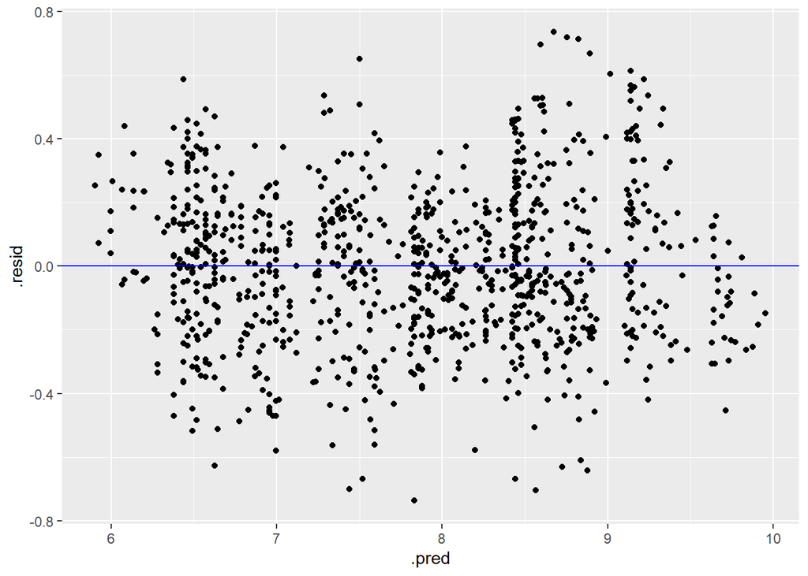

```r
augment(lm_fit, new_data = diamonds_data) |>
  ggplot(aes(y = .resid, x = .pred)) +
  geom_point() +
  geom_hline(yintercept = 0, color = "blue")
```

## 1.3. USE MODEL TO PREDICT

a) Using the model from the previous section, predict the price of diamonds with 1, 2 and 3 carat for cuts “Fair”, “Very Good” and “Ideal”. Build a plot of the predictions using a confidence interval of 90%.

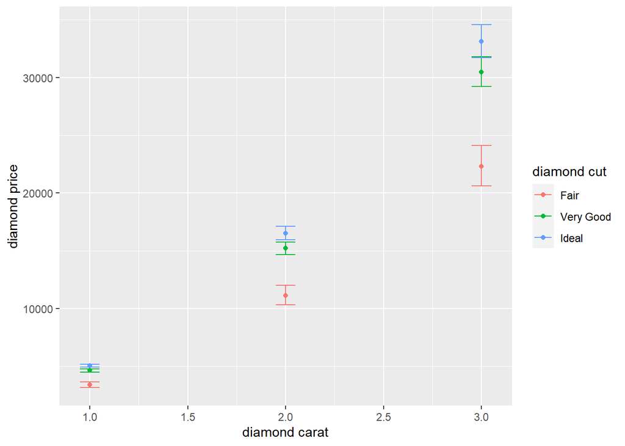

```r
new_points2 <- expand.grid(
  log_carat = log(1:3),
  fct_cut = c("Fair", "Very Good", "Ideal")
  )

bind_cols(
  new_points2,
  predict(lm_fit, new_data = new_points2),
  predict(lm_fit, new_data = new_points2, type = "conf_int", level = 0.90)
) |>
  ggplot(aes(x = exp(log_carat), color = fct_cut)) +
  geom_point(aes(y = exp(.pred))) +
  geom_errorbar(
    aes(ymin = exp(.pred_lower), ymax = exp(.pred_upper)),
    width = .1
  ) +
  labs(x = "diamond carat", y = "diamond price", color = "diamond cut")
```

# 2. BUILD A MODEL USING WORKFLOW

```r
library("nycflights13")
library("tidymodels")
library("tidyverse")
```

## 2.1. LOOK AT DATA

[no exercises]

## 2.2. SPLIT DATA

[no exercises]

## 2.3. CREATE WORKFLOW

a) Considering the following workflow, build a new workflow without the steps of the recipe. Look at the function add_formula().

```r
flights_rec <-
  recipe(arr_delay ~ ., data = train_data) |>
  step_date(date, features = c("dow", "month")) |>
  step_holiday(date, holidays = timeDate::listHolidays("US")) |>
  step_rm(date) |>
  step_dummy(all_nominal_predictors()) |>
  step_zv(all_predictors()) |>
  step_normalize(all_numeric_predictors())
flights_mod <- logistic_reg(engine = "glm")
flights_wflow <-
  workflow() |>
  add_model(flights_mod) |>
  add_recipe(flights_rec)
```

```r
flights_mod <- logistic_reg(engine = "glm")
flights_wflow2 <-
  workflow() |>
  add_model(flights_mod) |>
  add_formula(arr_delay ~ .)
```

## 2.4. FIT A MODEL

a) Using the given workflow and the newly created one, fit the two models to the following data set. Don’t forget to split the data in train and test sets.

```r
set.seed(123)
flight_data <- flights |>
  slice_sample(n = 10000) |>
  mutate(
    arr_delay = factor(ifelse(arr_delay >= 30, "late", "on_time")),
    date = lubridate::as_date(time_hour)
  ) |>
  select(dep_time, origin, dest, distance, carrier, date, arr_delay) |>
  na.omit() |>
  mutate(across(where(is.character), as.factor))
set.seed(456)
data_split <- initial_split(flight_data, prop = 3/4)
train_data <- training(data_split)
test_data  <- testing(data_split)
```

```r
set.seed(123)
flight_data <- flights |>
  slice_sample(n = 10000) |>
  mutate(
    arr_delay = factor(ifelse(arr_delay >= 30, "late", "on_time")),
    date = lubridate::as_date(time_hour)
  ) |>
  inner_join(weather, by = c("origin", "time_hour")) |>
  select(
    arr_delay,
    dep_time, origin, air_time, distance, date,
    humid, wind_dir, wind_speed, precip, pressure, visib
  ) |>
  na.omit() |>
  mutate(across(where(is.character), as.factor))

set.seed(456)
data_split <- initial_split(flight_data, prop = 3/4)
train_data <- training(data_split)
test_data  <- testing(data_split)

flights_mod <- logistic_reg(engine = "glm")

flights_rec <-
  recipe(arr_delay ~ ., data = train_data) |>
  step_date(date, features = c("dow", "month")) |>
  step_holiday(date, holidays = timeDate::listHolidays("US")) |>
  step_rm(date) |>
  step_dummy(all_nominal_predictors()) |>
  step_zv(all_predictors()) |>
  step_normalize(all_numeric_predictors())

flights_wflow <-
  workflow() |>
  add_model(flights_mod) |>
  add_recipe(flights_rec)

flights_wflow2 <-
  workflow() |>
  add_model(flights_mod) |>
  add_formula(arr_delay ~ .)

flights_fit <- flights_wflow |> fit(data = train_data)
flights_fit2 <- flights_wflow2 |>  fit(data = train_data)
```